# Gene Expression Variability Analysis (GSE15852)

Mohit Swami

2026-05-02

## Introduction

Gene expression profiling provides insights into molecular variability across biological samples and is widely used to study disease mechanisms. In this study, publicly available microarray data was analyzed to explore gene expression distribution and identify highly variable genes.

## Methods

Gene expression data (GSE15852) was obtained from the Gene Expression Omnibus (GEO). Data preprocessing included cleaning, conversion to numeric format, and assignment of gene identifiers.

Exploratory analysis included:

- Distribution of gene expression
- Sample comparison
- Identification of highly variable genes

## Data Processing

```r
data <- read.table("GSE15852_series_matrix.txt.gz",
                   skip = 100,
                   header = FALSE,
                   sep = "\t",
                   fill = TRUE,
                   quote = "")

colnames(data) <- data[1, ]
data <- data[-1, ]

gene_ids <- gsub('"', '', data[,1])

expr <- data[, -1]
expr <- apply(expr, 2, as.numeric)

rownames(expr) <- gene_ids

dim(expr)
```

```
## [1] 22262    86
```

## Results

### Gene Expression Distribution

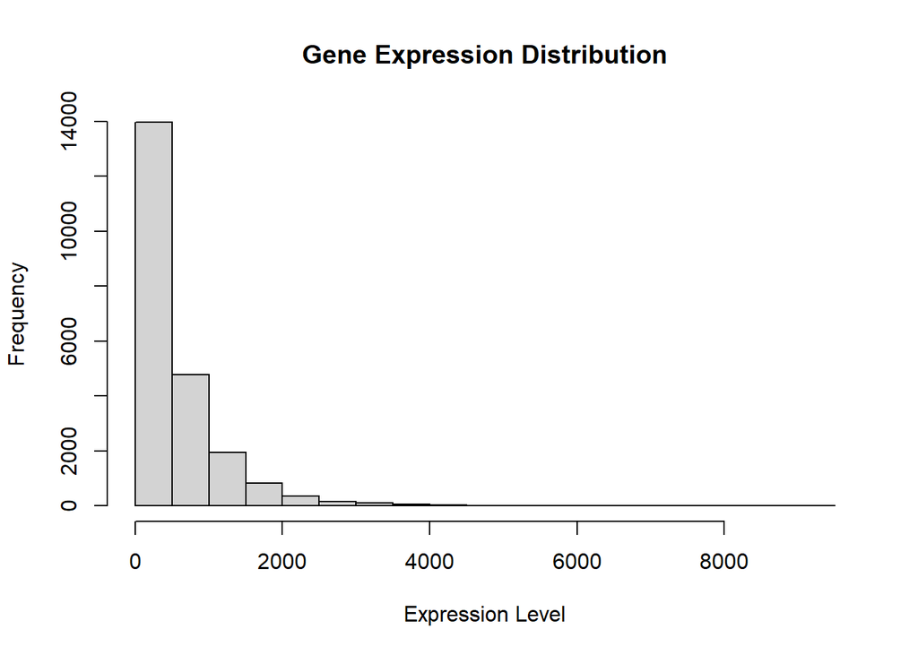

```r
hist(expr[,1],
     main="Gene Expression Distribution",
     xlab="Expression Level")
```

### Sample Comparison

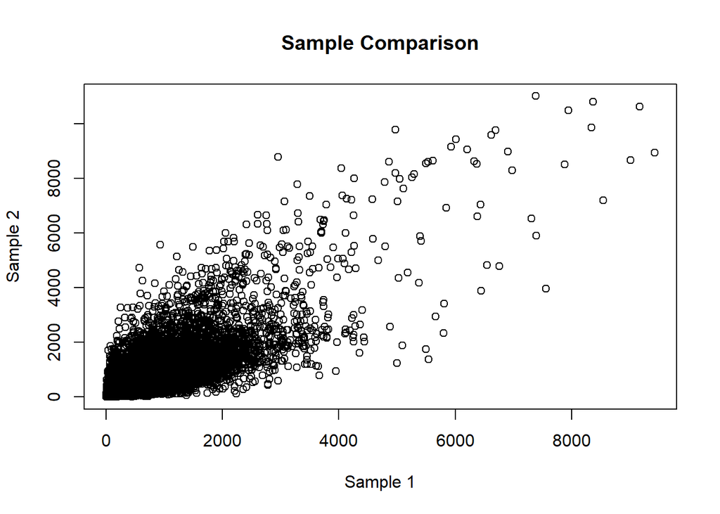

```r
plot(expr[,1], expr[,2],
     xlab="Sample 1",
     ylab="Sample 2",
     main="Sample Comparison")
```

### Highly Variable Genes

```r
gene_var <- apply(expr, 1, var, na.rm=TRUE)

top_genes <- names(sort(gene_var, decreasing=TRUE))[1:20]

top_genes
```

```
##  [1] "211696_x_at" "209116_x_at" "203980_at"   "211745_x_at" "213614_x_at"
##  [6] "204151_x_at" "212869_x_at" "217232_x_at" "212284_x_at" "215076_s_at"
## [11] "214414_x_at" "212391_x_at" "214003_x_at" "206559_x_at" "201257_x_at"
## [16] "201540_at"   "215121_x_at" "200633_at"   "207175_at"   "202088_at"
```

### Gene Mapping

```r
library(hgu133a.db)

mapped <- mapIds(hgu133a.db,
                 keys = top_genes,
                 column = "SYMBOL",
                 keytype = "PROBEID",
                 multiVals = "first")

data.frame(Probe = names(mapped), Gene = mapped)
```

```
##                   Probe    Gene
## 211696_x_at 211696_x_at     HBB
## 209116_x_at 209116_x_at     HBB
## 203980_at     203980_at   FABP4
## 211745_x_at 211745_x_at    HBA1
## 213614_x_at 213614_x_at  EEF1A1
## 204151_x_at 204151_x_at  AKR1C1
## 212869_x_at 212869_x_at    TPT1
## 217232_x_at 217232_x_at     HBB
## 212284_x_at 212284_x_at    TPT1
## 215076_s_at 215076_s_at  COL3A1
## 214414_x_at 214414_x_at    HBA1
## 212391_x_at 212391_x_at   RPS3A
## 214003_x_at 214003_x_at   RPS20
## 206559_x_at 206559_x_at  EEF1A1
## 201257_x_at 201257_x_at   RPS3A
## 201540_at     201540_at    FHL1
## 215121_x_at 215121_x_at   IGLC1
## 200633_at     200633_at     UBB
## 207175_at     207175_at  ADIPOQ
## 202088_at     202088_at SLC39A6
```

## Discussion

Analysis revealed a broad distribution of gene expression values and variability across samples.

Several highly variable genes identified include hemoglobin genes (HBB, HBA1), ribosomal proteins (RPS3A, RPS20), and metabolic regulators (FABP4, AKR1C1, ADIPOQ).

The presence of hemoglobin-related genes may reflect sample composition or microenvironmental factors. Additionally, genes involved in metabolism and cellular processes suggest biological heterogeneity across samples.

## Conclusion

This exploratory analysis demonstrates how publicly available gene expression datasets can be used to identify biologically relevant patterns. Highly variable genes identified in this study may serve as candidates for further functional investigation.